# Aprendizaje Automático

# Introducción al Aprendizaje Automático

##### Prof. Wladimir Rodríguez

##### wladimir@ula.ve

##### Departamento de Computación

# Información General

- **Profesor:**
  - Dr. Wladimir Rodriguez
- **Horario:**
  - Martes de 8:00 a 10:00 y Jueves de 8:00 a 10:00, Salón: Postgrado de Computación
- **Horas de Oficina:**
  - Martes y Jueves de 10:00 a 12:00, Salón: Postgrado de Computación
- **Material:**
  - https://github.com/wladrod/AprendizajeAutomatico2024

# Descripción

- El Aprendizaje Automático (o Machine Learning) es una rama de la Inteligencia Artificial que se dedica al estudio de los programas que aprenden a realizar una tarea en base a la experiencia.
- Esta asignatura presenta una visión general del aprendizaje automático. Durante el curso, se estudian los principales métodos, incluyendo aprendizaje supervisado, no supervisado y aprendizaje por refuerzo. Además, se incluyen ejercicios y ejemplos prácticas que permiten afianzar los conocimientos

## Temario:

### Unidad 1: Introducción al Aprendizaje Automático

- **Tema 1:** Definición. Aspectos y Características del Aprendizaje Automático
- **Tema 2:** Herramientas de Python

### Unidad 2: Aprendizaje Supervisado

- **Tema 1:** Tipos de Aprendizaje Automático: Clasificación y Regresión
- **Tema 2:** Regresión Lineal
- **Tema 3:** Clasificador Bayesiano Ingenuo (Naive Bayes)
- **Tema 4:** Perceptrón
- **Tema 5:** Regresión Logística
- **Tema 6:** Maquinas de Vectores de Soporte
- **Tema 7:** Vecino más Cercano
- **Tema 8:** Arboles de Decisión
- **Tema 9:** Random Forest
- **Tema 10:** Ensemble Learning (Aprendizaje con Ensamble de Algoritmos)

### Unidad 3: Redes Neuronales

- **Tema 1:** Introducción a las Redes Neuronales
- **Tema 2:** Aprendizaje Profundo
- **Tema 3:** Redes Convolucionales
- **Tema 4:** Redes Recurrentes
- **Tema 5:** Nuevas Arquitecturas de Redes Neuronales

### Unidad 4: Aprendizaje no Supervisado

- **Tema 1:** Análisis de Componentes Principales
- **Tema 2:** Agrupamiento
- **Tema 3:** Agrupamiento Jerárquico

### Unidad 5: Aprendizaje por Refuerzo

- **Tema 1:** Introducción al Aprendizaje por Refuerzo
- **Tema 2:** Aprendizaje Q
- **Tema 3:** Estado del Arte del Aprendizaje por Refuerzo

# Evaluación

- Tareas semanales: 40%
- Asistencia y participación en clase: 5%
- Proyecto final: 55%

# Agenda:

1. Aprendizaje
2. ¿Qué es el Aprendizaje Automático?
3. Inteligencia Artificial, Aprendizaje Automático, Aprendizaje Profundo
4. Aprendizaje Automático y Ciencias de Datos
5. Historia del Aprendizaje Automático
6. Aplicaciones de Aprendizaje Automático
7. Proceso de Aprendizaje Automático
8. Tipos de Aprendizaje Automático
9. Aprendizaje Supervisado
10. Aprendizaje No Supervisado
11. Aprendizaje por Refuerzo
12. Generación del Modelo de Aprendizaje
13. Ambiente para el Aprendizaje Automático y el Aprendizaje Profundo
14. Demo

# Aprendizaje:

- En un sentido amplio, aprendizaje se refiere al proceso mediante el cual los individuos adquieren nuevos conocimientos, habilidades, actitudes o valores a través de la experiencia, la educación, la instrucción, el estudio o la observación. Este proceso puede involucrar cambios en el comportamiento, la comprensión y la percepción, y puede ser consciente o inconsciente. (ChatGPT)

El aprendizaje humano es un proceso complejo que involucra varias dimensiones:

1. **Cognitiva**: Adquisición de nuevos conocimientos a través del estudio, la observación, el razonamiento y la resolución de problemas.
2. **Conductual**: Desarrollo de nuevas habilidades y conductas mediante la práctica, la experiencia y la imitación.
3. **Afectiva**: Formación de actitudes, emociones, motivaciones y valores que influyen en la forma en que percibimos e interpretamos las situaciones.
4. **Social**: Aprendizaje a través de la interacción con otros, el modelado de roles, la colaboración y la enseñanza.

# ¿Qué es el Aprendizaje Automático?

- El aprendizaje automático, también conocido como *machine learning*, es un campo de la inteligencia artificial que se enfoca en el desarrollo de algoritmos que pueden aprender a partir de datos sin ser programados explícitamente. En otras palabras, los sistemas de aprendizaje automático aprenden por sí mismos a partir de la experiencia, mejorando su rendimiento en la realización de tareas específicas a medida que se exponen a más datos. (Gemini)
- Campo de estudio que da a los computadores la capacidad de aprender sin ser explícitamente programados. (Arthur Samuel, 1959)
- Aprendizaje Automático es predecir el futuro basado en el pasado. (Hal Daume III)
- Aprendizaje Automático es la programación de computadoras para optimizar un criterio de rendimiento utilizando datos de ejemplo o experiencia pasada. (Ethem Alpaydin)
- El objetivo del aprendizaje automático es desarrollar métodos que puedan detectar automáticamente los patrones en los datos y luego utilizar los patrones descubiertos para predecir los datos futuros u otros resultados de interés. (Kevin P. Murphy)
- El campo del reconocimiento de patrones se refiere al descubrimiento automático de regularidades en datos mediante el uso de algoritmos informáticos y con el uso de estas regularidades tomar acciones. (Christopher M. Bishop)

## Programación Tradicional vs Aprendizaje Automático

[figure not shown]

## El Mundo del Aprendizaje Automático

[figure not shown]

### Inteligencia Artificial, Aprendizaje Automático, Aprendizaje Profundo

[figure not shown]

# Aprendizaje Automático y Ciencias de Datos

[figure not shown]

# Historia del Aprendizaje Automático

Basado en:  
https://roboticsbiz.com/machine-learning-the-complete-history-in-a-timeline/

- **Siglo VIII**: desarrollo de métodos estadísticos: varios conceptos vitales en el aprendizaje automático se derivan de la teoría de la probabilidad y las estadísticas, y se remontan al siglo XVIII. En 1763, el estadístico inglés Thomas Bayes estableció un teorema matemático para la probabilidad condicional, que se conoció como Teorema de Bayes y sigue siendo un concepto central en algunos enfoques modernos del aprendizaje automático.
- **1950** — La prueba de Turing: los artículos del matemático inglés Alan Turing en la década de 1940 estaban llenos de ideas sobre la inteligencia artificial. “¿Pueden pensar las máquinas?” Preguntó. En 1950, sugirió una prueba para la inteligencia de las máquinas, más tarde conocida como la Prueba de Turing, en la que una máquina se llama "inteligente" si sus respuestas a las preguntas pueden convencer a un humano.
- **1952** — Juego de Damas: En 1952, el investigador Arthur Samuel creó una máquina de aprendizaje automatico, capaz de aprender a jugar a las damas. Usó guías anotadas por expertos humanos y jugó contra sí mismo para aprender a distinguir los movimientos correctos de los malos.
- **1956** — El Taller de Dartmouth: El término "inteligencia artificial" nació durante el Taller de Dartmouth en 1956, que es ampliamente considerado como el evento fundacional de la inteligencia artificial como campo. El taller duró de seis a ocho semanas y asistieron matemáticos y científicos, incluido el informático John McCarthy, Marvin Minsky, Nathaniel Rochester y Claude Shannon.
- **1957** — El Perceptrón del célebre psicólogo estadounidense Frank Rosenblatt fue uno de los primeros intentos de crear una red neuronal con el uso de una resistencia rotatoria (potenciómetro) impulsada por un motor eléctrico. La máquina podría tomar una entrada (como píxeles de imágenes) y crear una salida (como etiquetas).
- **1967** — Algoritmo del vecino más cercano: la regla del vecino más cercano es un clásico en el reconocimiento de patrones, que apareció en varios trabajos de investigación en la década de 1960, especialmente en un artículo escrito por T. Cover y P. Hart en 1967. El algoritmo mapeó un ruta para vendedores ambulantes, comenzando en una ciudad aleatoria pero asegurándose de visitar todas las ciudades durante un recorrido corto.
- **1973**: El informe Lighthill y el invierno de la IA: el Consejo de Investigación Científica del Reino Unido publicó el informe Lighthill de James Lighthill en 1973, que presenta un pronóstico muy pesimista en el desarrollo de aspectos centrales en la investigación de la IA. Afirmó que "en ninguna parte del campo los descubrimientos realizados hasta ahora produjeron el gran impacto que se prometió en ese momento". Como resultado, el gobierno británico recortó los fondos para la investigación de IA en todas las universidades excepto en dos. Este período de financiación e interés reducidos se conoce como invierno IA.
- **1979** — Stanford Cart: los estudiantes de la Universidad de Stanford inventaron un robot llamado Cart, conectado por radio a una gran computadora central, que puede sortear obstáculos en una habitación por sí solo. Aunque cruzar toda la habitación tomó cinco horas debido a errores y mapas apenas adecuados, la invención era lo último en tecnología en ese momento.
- **1981** — Aprendizaje basado en explicaciones: Gerald Dejong introdujo el concepto de aprendizaje basado en explicaciones, que analiza datos y crea una regla general que puede seguir descartando datos sin importancia.
- **1985** — NetTalk: El profesor Terry Sejnowski inventó NetTalk, un programa que aprende a pronunciar un texto escrito en inglés mostrándole el texto como entrada y haciendo coincidir las transcripciones fonéticas para comparar. La intención era construir modelos simplificados que pudieran arrojar luz sobre el aprendizaje humano.
- **1986** — Procesamiento distribuido en paralelo y modelos de redes neuronales: David Rumelhart y James McClelland publicaron Procesamiento distribuido en paralelo, que avanzó en el uso de modelos de redes neuronales para el aprendizaje automático.
- **1992** — Jugando al backgammon: el investigador Gerald Tesauro creó un programa basado en una red neuronal artificial, que era capaz de jugar al backgammon con habilidades que igualaban a los mejores jugadores humanos.
- **1997** — Deep Blue: Deep Blue de IBM se convirtió en el primer sistema informático de juego de ajedrez en vencer al actual campeón mundial de ajedrez. Deep Blue usó el poder de la computación en la década de 1990 para realizar búsquedas a gran escala de movimientos potenciales y seleccionar el mejor movimiento.
- **2006** — Aprendizaje profundo: Geoffrey Hinton creó el término "aprendizaje profundo" para explicar los nuevos algoritmos que ayudan a las computadoras a distinguir objetos y texto en imágenes y videos.
- **2010** — Kinect: Microsoft desarrolló el dispositivo de entrada de detección de movimiento llamado Kinect que puede rastrear 20 características humanas a una velocidad de 30 veces por segundo. Permitió a las personas interactuar con la computadora a través de movimientos y gestos.
- **2011** — Watson y Google Brain: Watson de IBM ganó un juego del concurso estadounidense Jeopardy contra dos de sus campeones. En el mismo año, Google Brain desarrolló su red neuronal profunda que podía descubrir y categorizar objetos de la forma en que lo hace un gato.
- **2012**: Clasificación de ImageNet y visión por computadora: el año vio la publicación de un influyente artículo de investigación de Alex Krizhevsky, Geoffrey Hinton e Ilya Sutskever, que describe un modelo que puede reducir drásticamente la tasa de error en los sistemas de reconocimiento de imágenes. Mientras tanto, X Lab de Google desarrolló un algoritmo de aprendizaje automático capaz de navegar de forma autónoma en videos de YouTube para identificar los videos que contienen gatos.
- **2014** — DeepFace: Facebook desarrolló un algoritmo de software DeepFace, que puede reconocer y verificar personas en fotos con una precisión humana.
- **2015** — Amazon Machine Learning: Andy Jassy de AWS lanzó sus servicios administrados de Machine Learning que analizan los datos históricos de los usuarios para buscar patrones e implementar modelos predictivos. En el mismo año, Microsoft creó el kit de herramientas de aprendizaje automático distribuido, que permite la distribución eficiente de problemas de aprendizaje automático en varias computadoras.
- **2016**: AlphaGo: creado por investigadores de Google DeepMind para jugar el antiguo juego chino de Go, ganó cuatro de cinco partidos contra Lee Sedol, quien ha sido el mejor jugador de Go del mundo durante más de una década.
- **2017** — Libratus y Deepstack: Investigadores de la Universidad Carnegie Mellon crearon un sistema llamado Libratus, y derrotó a cuatro de los mejores jugadores en No Limit Texas Hold 'em, luego de 20 días de juego en 2017. Investigadores de la Universidad de Alberta también reportaron un éxito similar con su sistema, Deepstack.
- **2017** - AlphaZero es un programa informático desarrollado por la empresa de investigación de inteligencia artificial DeepMind para dominar los juegos de ajedrez, shogi y go. Este algoritmo utiliza un enfoque similar a AlphaGo Zero.
- **2020**: GPT-3. OpenAI GPT-3 se presentó por primera vez en mayo de 2020 y las pruebas beta comenzaron en junio de 2020. OpenAI GPT-3 es un modelo de lenguaje que genera texto mediante la adopción de algoritmos preentrenados.
- **2021**: AlphaFold es un programa de inteligencia artificial (IA) desarrollado por DeepMind de Alphabet/Google que realiza predicciones de la estructura de las proteínas. El programa está diseñado como un sistema de aprendizaje profundo.
- **2022**: ChapGPT y Stable Diffusion

# Aplicaciones del Aprendizaje Automático

- **Asistentes personales virtuales:** Alexa, Bixby, Cortana, Google Assistant, Siri son algunos de los ejemplos populares de asistentes personales virtuales. Como su nombre indica, ayudan a encontrar información cuando se les pregunta por voz. Todo lo que necesita hacer es activarlos y preguntar "¿Cuál es mi horario para hoy?", "¿Cuáles son los vuelos de Alemania a Londres?"
- **Diagnóstico médico:** se utiliza para analizar imágenes médicas y datos etiquetados para detectar enfermedades como el cáncer.
- **Detección de spam:** se utiliza para clasificar los correos electrónicos entre spam o no spam según sus características.
- **Detección de fraude:** se utiliza para identificar patrones anómalos o sospechosos en los datos financieros o de transacciones.
- **Segmentación de imágenes:** se utiliza para dividir imágenes en partes según sus etiquetas o categorías.
- **Sistemas de recomendación:** se utiliza para sugerir productos, servicios o contenidos personalizados a los usuarios según sus preferencias o comportamientos.
- **Aprendizaje personalizado:** se utiliza para adaptar el proceso educativo a las necesidades y ritmos de cada estudiante.
- **Los modelos de lenguaje de gran escala (LLM):** que se entrenan con grandes cantidades de texto para aprender a generar o comprender el lenguaje natural. Estos modelos pueden tener diversas aplicaciones en el aprendizaje automático, como la generación de texto, la comprensión de lectura, la traducción automática, el resumen de texto, la respuesta a preguntas, el análisis de sentimientos y la clasificación de texto

# Proceso del Aprendizaje Automático

[figure not shown]

# Tipos de Aprendizaje Automático

[figure not shown]

## Aprendizaje Supervisado

Es una técnica para deducir una función a partir de datos de entrenamiento. Los datos de entrenamiento consisten de pares de objetos (normalmente vectores): un componente del par son los datos de entrada y el otro, los resultados deseados. La salida de la función puede ser un valor numérico (como en los problemas de regresión) o una etiqueta de clase (como en los de clasificación). El objetivo del aprendizaje supervisado es el de crear una función capaz de predecir el valor correspondiente a cualquier objeto de entrada válido después de haber visto una serie de ejemplos, los datos de entrenamiento. Para ello, tiene que generalizar a partir de los datos presentados a las situaciones no vistas previamente. (Wikipedia)

# Clasificación y Regresión

[figure not shown]

# Ejemplo Clasificación

[figure not shown]

## Aprendizaje No Supervisado

Es un método de Aprendizaje Automático donde un modelo es ajustado a las observaciones. Se distingue del Aprendizaje Supervisado por el hecho de que no hay un conocimiento a priori. En el aprendizaje no supervisado, un conjunto de datos de objetos de entrada es tratado. Así, el aprendizaje no supervisado típicamente trata los objetos de entrada como un conjunto de variables aleatorias, siendo construido un modelo de densidad para el conjunto de datos. (Wikipedia)

# Agrupamiento

[figure not shown]

# Ejemplo de Agrupamiento

[figure not shown]

## Aprendizaje por Refuerzo

Es un área del aprendizaje automático inspirada en la psicología conductista, cuya ocupación es determinar qué acciones debe escoger un agente de software en un entorno dado con el fin de maximizar alguna noción de "recompensa" o premio acumulado.

# Agente - Ambiente

[figure not shown]

# Generación del Modelo de Aprendizaje

[figure not shown]

# Demostración

## Ejemplo de Inicio a Fin de un Problema de Aprendizaje Automático

## Agenda

- Introducción
- Descripción de datos
- Exploración de datos
- Preparación de datos
- Entrenamiento y evaluación del modelo de aprendizaje automático
- Interpretando el modelo de aprendizaje automático
- Guardar el modelo
- Hacer predicciones con el modelo

## Introducción

Usaremos Aprendizaje Automático para predecir si una persona tiene diabetes o no, a partir de la información sobre el paciente, como la presión arterial, el índice de masa corporal (IMC), la edad, etc.

Los datos fueron recopilados y puestos a disposición por el "Instituto Nacional de Diabetes y Enfermedades Digestivas y Renales" como parte de la base de datos de diabetes de los [Pima Indians](https://www.kaggle.com/uciml/pima-indians-diabetes-database/data).

Utilizaremos `Python` y algunos de sus populares librerías relacionados con la ciencia de datos. En primer lugar, importaremos `pandas` para leer nuestros datos de un archivo CSV y manipularlos para su uso posterior. También utilizaremos `Numpy` para convertir datos en un formato adecuado para alimentar nuestro modelo de clasificación. Usaremos `seaborn` y `matplotlib` para las visualizaciones. A continuación, importaremos el algoritmo de Regresión Logística de `sklearn`. Este algoritmo nos ayudará a construir nuestro modelo de clasificación. Por último, utilizaremos la librería `joblib` para guardar nuestro modelo para uso futuro.

```python
import pandas as pd
import numpy as np
import seaborn as sns
import matplotlib.pyplot as plt
%matplotlib inline
from sklearn.linear_model import LogisticRegression
import joblib
```

## Descripción de los Datos

```python
diabetes = pd.read_csv('../datos/diabetes.csv')
diabetes.head(10)
```

|  | Pregnancies | Glucose | BloodPressure | SkinThickness | Insulin | BMI | DiabetesPedigreeFunction | Age | Outcome |
| --- | --- | --- | --- | --- | --- | --- | --- | --- | --- |
| 0 | 6 | 148 | 72 | 35 | 0 | 33.6 | 0.627 | 50 | 1 |
| 1 | 1 | 85 | 66 | 29 | 0 | 26.6 | 0.351 | 31 | 0 |
| 2 | 8 | 183 | 64 | 0 | 0 | 23.3 | 0.672 | 32 | 1 |
| 3 | 1 | 89 | 66 | 23 | 94 | 28.1 | 0.167 | 21 | 0 |
| 4 | 0 | 137 | 40 | 35 | 168 | 43.1 | 2.288 | 33 | 1 |
| 5 | 5 | 116 | 74 | 0 | 0 | 25.6 | 0.201 | 30 | 0 |
| 6 | 3 | 78 | 50 | 32 | 88 | 31.0 | 0.248 | 26 | 1 |
| 7 | 10 | 115 | 0 | 0 | 0 | 35.3 | 0.134 | 29 | 0 |
| 8 | 2 | 197 | 70 | 45 | 543 | 30.5 | 0.158 | 53 | 1 |
| 9 | 8 | 125 | 96 | 0 | 0 | 0.0 | 0.232 | 54 | 1 |

- **Pregnancies**: Número de veces embarazada
- **Glucose**: concentración plasmática de glucosa durante 2 horas en una prueba oral de tolerancia a la glucosa
- **BloodPressure**: presión arterial diastólica (mm Hg)
- **SkinThickness**: espesor del pliegue de la piel del tríceps (mm)
- **Insulin**: insulina sérica de 2 horas (mu U / ml)
- **BMI**: índice de masa corporal (peso en kg/(altura en m)^2)
- **DiabetesPedigreeFunction**: función de pedigrí de la diabetes (una función que puntúa la probabilidad de diabetes según el historial familiar)
- **Age**: Edad (años)
- **Outcome**: variable de clase (0 si no es diabético, 1 si es diabético)

También asegurémonos de que nuestros datos estén limpios (no tiene valores nulos, etc.).

```python
diabetes.info()
```

```
<class 'pandas.core.frame.DataFrame'>
RangeIndex: 768 entries, 0 to 767
Data columns (total 9 columns):
 #   Column                    Non-Null Count  Dtype
---  ------                    --------------  -----
 0   Pregnancies               768 non-null    int64
 1   Glucose                   768 non-null    int64
 2   BloodPressure             768 non-null    int64
 3   SkinThickness             768 non-null    int64
 4   Insulin                   768 non-null    int64
 5   BMI                       768 non-null    float64
 6   DiabetesPedigreeFunction  768 non-null    float64
 7   Age                       768 non-null    int64
 8   Outcome                   768 non-null    int64
dtypes: float64(2), int64(7)
memory usage: 54.1 KB
```

## Exploración de datos

Exploremos ahora nuestro conjunto de datos para tener una idea de cómo se ve y obtener algunas ideas al respecto.

Comencemos por encontrar la correlación de cada par de atributos (y la variable de resultado), y visualicemos las correlaciones usando un mapa de calor.

```python
corr = diabetes.corr()
corr
```

|  | Pregnancies | Glucose | BloodPressure | SkinThickness | Insulin | BMI | DiabetesPedigreeFunction | Age | Outcome |
| --- | --- | --- | --- | --- | --- | --- | --- | --- | --- |
| Pregnancies | 1.000000 | 0.129459 | 0.141282 | -0.081672 | -0.073535 | 0.017683 | -0.033523 | 0.544341 | 0.221898 |
| Glucose | 0.129459 | 1.000000 | 0.152590 | 0.057328 | 0.331357 | 0.221071 | 0.137337 | 0.263514 | 0.466581 |
| BloodPressure | 0.141282 | 0.152590 | 1.000000 | 0.207371 | 0.088933 | 0.281805 | 0.041265 | 0.239528 | 0.065068 |
| SkinThickness | -0.081672 | 0.057328 | 0.207371 | 1.000000 | 0.436783 | 0.392573 | 0.183928 | -0.113970 | 0.074752 |
| Insulin | -0.073535 | 0.331357 | 0.088933 | 0.436783 | 1.000000 | 0.197859 | 0.185071 | -0.042163 | 0.130548 |
| BMI | 0.017683 | 0.221071 | 0.281805 | 0.392573 | 0.197859 | 1.000000 | 0.140647 | 0.036242 | 0.292695 |
| DiabetesPedigreeFunction | -0.033523 | 0.137337 | 0.041265 | 0.183928 | 0.185071 | 0.140647 | 1.000000 | 0.033561 | 0.173844 |
| Age | 0.544341 | 0.263514 | 0.239528 | -0.113970 | -0.042163 | 0.036242 | 0.033561 | 1.000000 | 0.238356 |
| Outcome | 0.221898 | 0.466581 | 0.065068 | 0.074752 | 0.130548 | 0.292695 | 0.173844 | 0.238356 | 1.000000 |

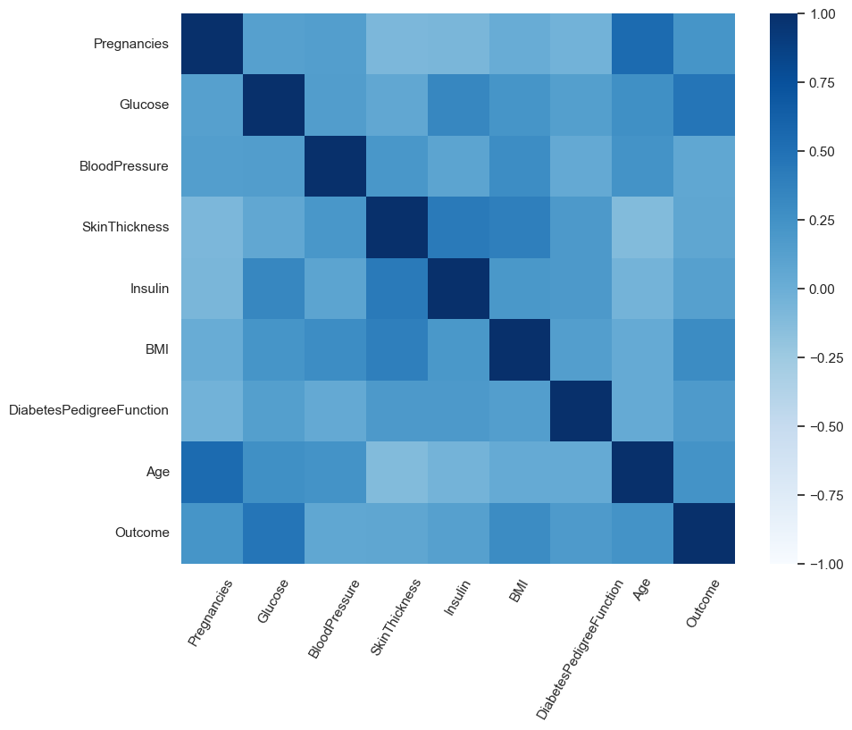

```python
sns.set(rc={"figure.figsize": (10, 8)})
ax = sns.heatmap(corr, xticklabels=corr.columns, yticklabels=corr.columns, cmap='Blues', vmin=-1, vmax=1)
ax.set_xticklabels(ax.get_xticklabels(),rotation = 60);
```

En el mapa de calor anterior, los colores más oscuros indican una mayor correlación. Como podemos ver en la tabla y en el mapa de calor, los niveles de glucosa, la edad, el IMC y el número de embarazos tienen una correlación significativa con la variable de resultado. También observe la correlación entre los pares de atributos, como la edad y los embarazos, o la insulina y el grosor de la piel.

Observemos también cuántas personas en el conjunto de datos son diabéticas y cuántas no. A continuación se muestra un gráfico de barras:

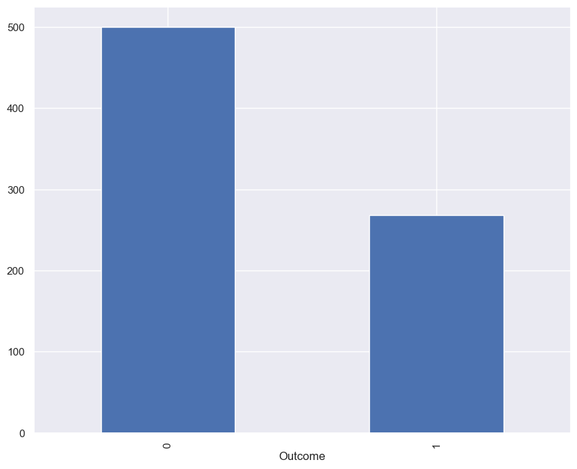

```python
diabetes.Outcome.value_counts().plot.bar()
```

También es útil visualizar las relaciones entre una sola variable y el resultado. A continuación, veremos la relación entre `Age` y `Outcome`.

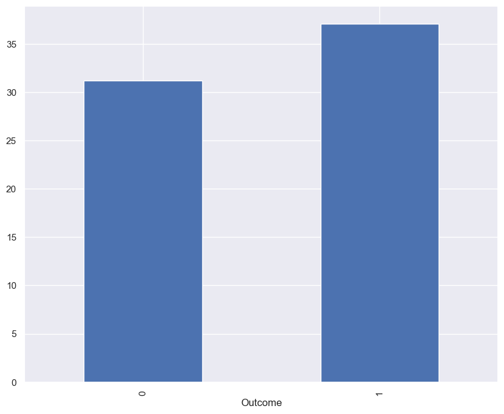

```python
diabetes.groupby("Outcome")["Age"].mean().plot.bar()
```

## Preparación del Conjunto de Datos

Al usar algoritmos de aprendizaje automático, siempre debemos dividir nuestros datos en un conjunto de entrenamiento y un conjunto de prueba. Usaremos la función `train_test_split` de sklearn para dividir el conjunto de datos. Dividiremos el conjunto datos en 80% para el conjunto de entrenamiento y 20% para el conjunto de prueba.

Primero separaemos los atributos y la salida del conjunto de datos.

```python
from sklearn.model_selection import train_test_split
salida = diabetes.Outcome
atributos = diabetes.drop('Outcome', axis=1)
X_entrenamiento, X_prueba, y_entrenamiento, y_prueba = train_test_split(atributos, salida,
                                                                        test_size = 0.2,
                                                                        random_state=42)
X_entrenamiento.head()
```

|  | Pregnancies | Glucose | BloodPressure | SkinThickness | Insulin | BMI | DiabetesPedigreeFunction | Age |
| --- | --- | --- | --- | --- | --- | --- | --- | --- |
| 60 | 2 | 84 | 0 | 0 | 0 | 0.0 | 0.304 | 21 |
| 618 | 9 | 112 | 82 | 24 | 0 | 28.2 | 1.282 | 50 |
| 346 | 1 | 139 | 46 | 19 | 83 | 28.7 | 0.654 | 22 |
| 294 | 0 | 161 | 50 | 0 | 0 | 21.9 | 0.254 | 65 |
| 231 | 6 | 134 | 80 | 37 | 370 | 46.2 | 0.238 | 46 |

Como paso final antes de usar el aprendizaje automático, normalizaremos nuestras entradas. Los modelos de Aprendizaje Automático a menudo se benefician sustancialmente de la normalización de las entradas. También nos facilita la comprensión de la importancia de cada atributo más adelante, cuando observemos los pesos del modelo. Normalizaremos los datos de modo que cada atributo tenga media 0 y desviación estándar de 1.

Usaremos `StandardScaler` de sklearn para normalizar los datos.

```python
from sklearn.preprocessing import StandardScaler
sc = StandardScaler()
sc.fit(X_entrenamiento)
X_entrenamiento = sc.transform(X_entrenamiento)
X_prueba = sc.transform(X_prueba)
```

## Entrenamiento y Evaluación del Modelo de Aprendizaje Automático

Ahora podemos entrenar nuestro modelo de clasificación. Usaremos un modelo de aprendizaje automático simple llamado regresión logística. Dado que el modelo está disponible en `sklearn`, el proceso de entrenamiento es bastante fácil y podemos hacerlo en pocas líneas de código. Primero, creamos una instancia llamada `Modelo_Diabetes` y luego usamos la función `fit` para entrenar el modelo.

```python
Modelo_Diabetes = LogisticRegression()
Modelo_Diabetes.fit(X_entrenamiento, y_entrenamiento)
```

```
LogisticRegression()
```

A continuación, utilizaremos nuestros datos de prueba para conocer la exactitud del modelo.

```python
exactitud = Modelo_Diabetes.score(X_prueba, y_prueba)
print("exactitud = ", exactitud * 100, "%")
```

```
exactitud =  75.32467532467533 %
```

## Interpretación del Modelo

Para tener una mejor idea de lo que está sucediendo dentro del modelo de regresión logística, podemos visualizar cómo nuestro modelo usa los diferentes atributos y qué atributos tienen un mayor efecto.

```python
coeficientes = list(Modelo_Diabetes.coef_[0])
etiquetas = list(atributos.columns)
importancia = pd.DataFrame()
importancia['Atributos'] = etiquetas
importancia['importancia'] = coeficientes
importancia.sort_values(by=['importancia'], ascending=True, inplace=True)
importancia['positiva'] = importancia['importancia'] > 0
importancia.set_index('Atributos', inplace=True)
importancia
```

| Atributos | importancia | positiva |
| --- | --- | --- |
| BloodPressure | -0.247842 | False |
| Insulin | -0.200827 | False |
| SkinThickness | 0.045697 | True |
| Pregnancies | 0.212558 | True |
| DiabetesPedigreeFunction | 0.230607 | True |
| Age | 0.421002 | True |
| BMI | 0.778152 | True |
| Glucose | 1.071132 | True |

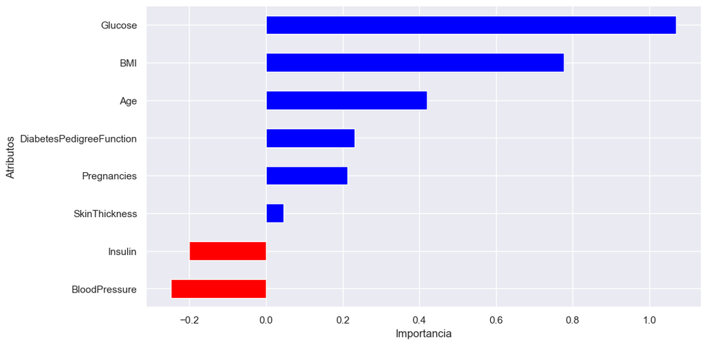

```python
importancia.importancia.plot(kind='barh', figsize=(11, 6),color = importancia.positiva.map({True: 'blue', False: 'red'}))
plt.xlabel('Importancia');
```

## Guardar el Modelo

Ahora guardaremos nuestro modelo entrenado para uso futuro usando `joblib`

```python
joblib.dump(Modelo_Diabetes, 'Modelo_Diabetes.pkl')
```

```
['Modelo_Diabetes.pkl']
```

Para verificar si hemos guardado el modelo correctamente o no, usaremos nuestros datos de prueba para verificar la precisión de nuestro modelo guardado

```python
Modelo = joblib.load('Modelo_Diabetes.pkl')
exactitud_modelo = Modelo.score(X_prueba, y_prueba)
print("exactitud = ", exactitud_modelo * 100,"%")
```

```
exactitud =  75.32467532467533 %
```

A continuación mostraremos tres ejemplos:

- Predicción correcta (no diabetes)
- Predicción correcta (diabetes)
- Predicción incorrecta

```python
muestra = X_prueba[0,:].reshape(1, -1)
probabilidad_prediccion  = Modelo.predict_proba(muestra)
prediccion = Modelo.predict(muestra)
print('Probabilidad:', probabilidad_prediccion)
print('Prediction:', prediccion)
print('Salida Real:', y_prueba.iloc[0])
```

```
Probabilidad: [[0.72266096 0.27733904]]
Prediction: [0]
Salida Real: 0
```

```python
muestra = X_prueba[18,:].reshape(1, -1)
probabilidad_prediccion  = Modelo.predict_proba(muestra)
prediccion = Modelo.predict(muestra)
print('Probabilidad:', probabilidad_prediccion)
print('Prediction:', prediccion)
print('Salida Real:', y_prueba.iloc[18])
```

```
Probabilidad: [[0.14221802 0.85778198]]
Prediction: [1]
Salida Real: 1
```

```python
muestra = X_prueba[15,:].reshape(1, -1)
probabilidad_prediccion  = Modelo.predict_proba(muestra)
prediccion = Modelo.predict(muestra)
print('Probabilidad:', probabilidad_prediccion)
print('Prediction:', prediccion)
print('Salida Real:', y_prueba.iloc[15])
```

```
Probabilidad: [[0.61368987 0.38631013]]
Prediction: [0]
Salida Real: 1
```

## Referencias:

[End-to-End Example: Using Logistic Regression for predicting Diabetes](https://www.commonlounge.com/discussion/d6b0c91db14245b8998afd2a5c0f5b83)